# Ch2 Reading and Manipulating

SOCI6630 Analysis and Interpretation of Sociological Data II

As we mentioned in previous chapter, set up your work directory by any of following methods, then you don’t have to type in the exact file path every time. Quick recap for you:

To set up your work directory, you can:

1. (**By code, Easiest!**) Type in the code `setwd("your/path")`, then you are all set!
2. (**In R**) Click `Misc` -> `Change Word Directory` -> Select the directory you put your file
3. (**In R Studio**) Click `Session` -> `Set Work Directory` -> `Choose Directory` -> Select the directory you put your file

## 2.1 Data Input

### 1. Keyboard Input

Entering data directly into R using the keyboard. It is useful if:

1. If the number of values is small, keyboard entry can be efficient.
2. R has a number of functions for quickly generating patterned data.

For large amouts of data, however, keyboard entry is likely to be inefficient and error-prone.

```r
x <- c(1, 2, 3, 4)
names <- c("John", "Sandy", "Mary")
v <- c(TRUE, FALSE)
```

You can create each column or each row by yourself, and then combine them as a data frame or list.

```r
cooperation <- c(49, 64, 37, 52, 68, 54, 61, 79, 64, 29, 27, 58, 52, 41, 30,
    40, 39, 44, 34, 44)
cooperation
condition <- rep(c("public", "anonymous"), c(10, 10))
condition
sex <- rep(rep(c("male", "female"), c(5, 5)), 2)
sex
Guyer <- data.frame(cooperation, condition, sex)
Guyer
```

```
>  [1] 49 64 37 52 68 54 61 79 64 29 27 58 52 41 30 40 39 44 34 44
```

```
>  [1] "public"    "public"    "public"    "public"    "public"
>  [6] "public"    "public"    "public"    "public"    "public"
> [11] "anonymous" "anonymous" "anonymous" "anonymous" "anonymous"
> [16] "anonymous" "anonymous" "anonymous" "anonymous" "anonymous"
```

```
>  [1] "male"   "male"   "male"   "male"   "male"   "female" "female"
>  [8] "female" "female" "female" "male"   "male"   "male"   "male"
> [15] "male"   "female" "female" "female" "female" "female"
```

```
>    cooperation condition    sex
> 1           49    public   male
> 2           64    public   male
> 3           37    public   male
> 4           52    public   male
> 5           68    public   male
> 6           54    public female
> 7           61    public female
> 8           79    public female
> 9           64    public female
> 10          29    public female
> 11          27 anonymous   male
> 12          58 anonymous   male
> 13          52 anonymous   male
> 14          41 anonymous   male
> 15          30 anonymous   male
> 16          40 anonymous female
> 17          39 anonymous female
> 18          44 anonymous female
> 19          34 anonymous female
> 20          44 anonymous female
```

### 2. `scan()`

`scan()` does the same thing as `c()` but without commas. Enter the data into the console:

```r
cooperation <- scan()
49 64 37 52 68 54
61 79 64 29
27 58 52 41 30 40 39
44 34 44
```

### 3. `read.table()`

#### (1) reads a data frame

```r
# Data in Local File
Prestige <- read.table("~/Documents/Prestige.txt", header = TRUE)
Prestige <- read.table("Prestige.txt", header = TRUE)
```

```r
# Data from the Internet
Prestige <- read.table("https://socialsciences.mcmaster.ca/jfox/Books/Companion/data/Prestige.txt",
    header = TRUE)
```

#### (2) Errors in rows

Firstly, take a look of the file `Prestige-bugged.txt`,

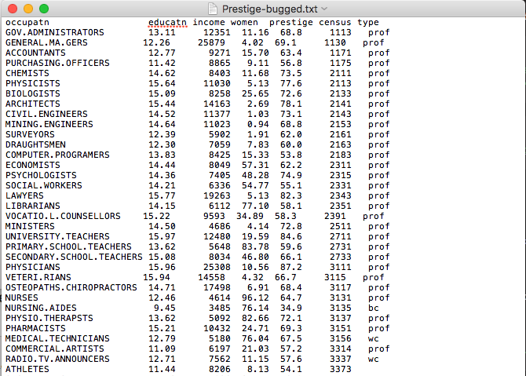

There are errors when loading the data and the error message as follows. Then we have to find out the rows without 7 elements.

```r
Prestige <- read.table("Prestige-bugged.txt", header = TRUE)
```

```
> Error in scan(file = file, what = what, sep = sep, quote = quote, dec = dec, : line 34 did not have 7 elements
```

Use `count.fields()` to detect the counts of elements in each row.

```r
file <- "Prestige-bugged.txt"
counts <- count.fields(file)
counts
```

```
>   [1] 7 7 7 7 7 7 7 7 7 7 7 7 7 7 7 7 7 7 7 7 7 7 7 7 7 7 7 7 7 7 7 7 7 7 6
>  [36] 7 7 7 7 7 7 7 7 7 7 7 7 7 7 7 7 7 7 6 7 7 7 7 7 7 7 7 7 6 7 7 7 6 7 7
>  [71] 7 7 7 7 7 7 7 7 7 7 7 7 7 7 7 7 7 7 7 7 7 7 7 7 7 7 7 7 7 7 7 7 7
```

```r
which(counts != 7)  # print the index of counts not equal to 7
```

```
> [1] 35 54 64 68
```

Then we can fix the rows with problems.

#### (3) some additional arguments

- `colClasses` - specify column modes (e.g. `colClasses = c('character', 'character', 'integer', 'integer')`)
- `col.names` - specify column names, similar in spirit to names() (specify the names of each column if your original dataset doesn’t specify them)
- `row.names` - specify row names
- `sep` - specify the delimiter, default: white space
- `skip` - number of lines to skip before reading
- `na.strings` - how missing values are recorded

### 4. `read.fwf()`

Use `read.fwf()` to import data when you want to specify the amount of words of each column. Take a look of the file `Prestige-fixed.txt`.

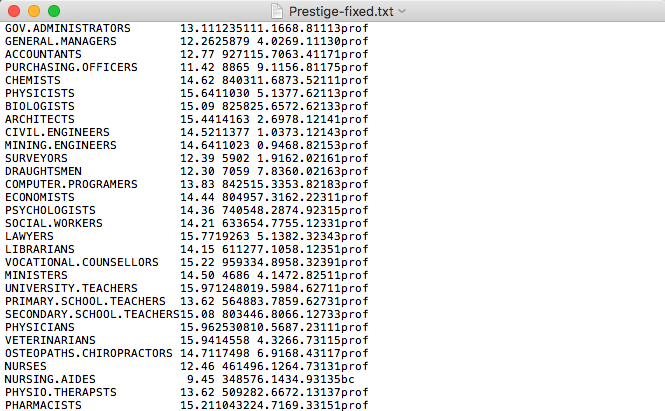

There are no white spaces or any kind of delimiter between each points, and there are no column names and row names. Then we specify ourselves.

```r
Prestige <- read.fwf("Prestige-fixed.txt", col.names = c("occupation", "education",
    "income", "women", "prestige", "census", "type"), row.names = "occupation",
    widths = c(25, 5, 5, 5, 4, 4, 4))
Prestige[1:10, ]
```

```
>                           education income women prestige census type
> GOV.ADMINISTRATORS            13.11  12351 11.16     68.8   1113 prof
> GENERAL.MANAGERS              12.26  25879  4.02     69.1   1130 prof
> ACCOUNTANTS                   12.77   9271 15.70     63.4   1171 prof
> PURCHASING.OFFICERS           11.42   8865  9.11     56.8   1175 prof
> CHEMISTS                      14.62   8403 11.68     73.5   2111 prof
> PHYSICISTS                    15.64  11030  5.13     77.6   2113 prof
> BIOLOGISTS                    15.09   8258 25.65     72.6   2133 prof
> ARCHITECTS                    15.44  14163  2.69     78.1   2141 prof
> CIVIL.ENGINEERS               14.52  11377  1.03     73.1   2143 prof
> MINING.ENGINEERS              14.64  11023  0.94     68.8   2153 prof
```

### 5. Built-in datasets

```r
data(Prestige, package = "car")
head(Prestige)  # first 6 rows
remove(Prestige)
```

```
>                     education income women prestige census type
> gov.administrators      13.11  12351 11.16     68.8   1113 prof
> general.managers        12.26  25879  4.02     69.1   1130 prof
> accountants             12.77   9271 15.70     63.4   1171 prof
> purchasing.officers     11.42   8865  9.11     56.8   1175 prof
> chemists                14.62   8403 11.68     73.5   2111 prof
> physicists              15.64  11030  5.13     77.6   2113 prof
```

### 6. To use R dataset you’ve already saved

```r
load("village.Rdata")
```

Then a dataset `village` you saved before will be loaded, you can call it by typing in `village`.

## 2.2 Working with Data Frames

### 2.2.2 Avoiding `attach()`

Use the dataset `Duncan.txt` used in chapter 1, as we mentioned before, we can access the columns in the dataset by following three methods:

1. **Use `$`**

```r
Duncan$prestige
```

2. **Use `[ ]` and Specify the column name**

```r
Duncan[, "prestige"]
```

3. **Use `attach()` to access all columns by names**

```r
attach(Duncan)
prestige
```

If you use the 3rd method to attach dataset `Duncan`, you can use `detach(Duncan)` at the end when you are done with it.

For the `mean()` function and `lm()` function we used in chapter 1, we can all access the columns without using `attach()` function. See following examples:

1. **with `attach()`**

```r
attach(Duncan)

# mean of prestige
mean(prestige)
# linear regression of prestige on income and education
lm(prestige ~ income + education)

detach(Duncan)
```

2. **without `attach()`**

```r
# mean of prestige
mean(Duncan$prestige)
# linear regression of prestige on income and education
lm(prestige ~ income + education, data = Duncan)
```

### 2.2.3 Missing Values

Use the built-in dataset `Freedman` in `car` package. If we meet missing values in the dataset, how do we proceed the arithmetic without considering them in the data? We use `na.rm` to specify this request.

```r
data(Freedman, package = "car")
head(Freedman$density, 20)  # first 20 values

mean(Freedman$density)
mean(Freedman$density, na.rm = TRUE)  # na.rm means NA-remove
median(Freedman$density, na.rm = TRUE)
```

```
>  [1]  746  322   NA  491 1612  770   41  877  240  147  272 1831 1252  832
> [15]  630   NA   NA  328  308 1832
```

```
> [1] NA
```

```
> [1] 765.67
```

```
> [1] 412
```

We can remove the data points with missing values (NA values):

```r
head(Freedman, 7)  # first 7 values
```

```
>             population nonwhite density crime
> Akron              675      7.3     746  2602
> Albany             713      2.6     322  1388
> Albuquerque         NA      3.3      NA  5018
> Allentown          534      0.8     491  1182
> Anaheim           1261      1.4    1612  3341
> Atlanta           1330     22.8     770  2805
> Bakersfield        331      7.0      41  3306
```

```r
Freedman.good <- na.omit(Freedman)
head(Freedman.good)
```

```
>             population nonwhite density crime
> Akron              675      7.3     746  2602
> Albany             713      2.6     322  1388
> Allentown          534      0.8     491  1182
> Anaheim           1261      1.4    1612  3341
> Atlanta           1330     22.8     770  2805
> Bakersfield        331      7.0      41  3306
```

Also, `is.na()` function determine the missing values for you.

```r
is.na(c(1, 2, NA, 4))
```

```
> [1] FALSE FALSE  TRUE FALSE
```

When you implement it to the whole dataset, it can also tell you the amount of missing values in the whole dataset.

```r
head(is.na(Freedman))
sum(is.na(Freedman))
```

```
>             population nonwhite density crime
> Akron            FALSE    FALSE   FALSE FALSE
> Albany           FALSE    FALSE   FALSE FALSE
> Albuquerque       TRUE    FALSE    TRUE FALSE
> Allentown        FALSE    FALSE   FALSE FALSE
> Anaheim          FALSE    FALSE   FALSE FALSE
> Atlanta          FALSE    FALSE   FALSE FALSE
```

```
> [1] 20
```

### 2.2.4 Numeric Variables and Factors

If we construct R data frames by reading data from text files using `read.table` or from numeric and character vectors using `data.frame`, then our data frames will consist of two kinds of data: **numeric variables** and **factors**. Both `read.table` and `data.frame` by default translate character data and logical data into factors.

A factor is a representation of a categorical variable. Factors are stored more economically than chracter vectors, and they are stored saves information about the levels (category set) of a factor. When a factor is printed, its values are not quoted, as are the values of a character vector, and the levels of the factor are listed.

Use the built-in dataset `Guyer` in `car` package here. We can always check each variables’ mode anytime:

```r
data(Guyer, package = "car")
head(Guyer)  # first 20 values
```

```
>   cooperation condition sex
> 1          49         P   M
> 2          64         P   M
> 3          37         P   M
> 4          52         P   M
> 5          68         P   M
> 6          54         P   F
```

```r
Guyer$condition
```

```
>  [1] P P P P P P P P P P A A A A A A A A A A
> Levels: A P
```

```r
is.character(Guyer$condition)
```

```
> [1] FALSE
```

```r
is.factor(Guyer$condition)
```

```
> [1] TRUE
```

```r
summary(Guyer)
```

```
>   cooperation    condition sex
>  Min.   :27.00   A:10      F:10
>  1st Qu.:38.50   P:10      M:10
>  Median :46.50
>  Mean   :48.30
>  3rd Qu.:58.75
>  Max.   :79.00
```

### 2.2.5 Modifying and Transforming Data

#### 1. Create new variabe based on other variables

```r
Guyer$perc.coop <- 100 * Guyer$cooperation/120
head(Guyer)  # first 6 rows
```

```
>   cooperation condition sex perc.coop
> 1          49         P   M  40.83333
> 2          64         P   M  53.33333
> 3          37         P   M  30.83333
> 4          52         P   M  43.33333
> 5          68         P   M  56.66667
> 6          54         P   F  45.00000
```

#### 2. Replace the original variables with a new variable

```r
Guyer$cooperation <- with(Guyer, log(perc.coop/(100 - perc.coop)))
head(Guyer)  # first 6 rows
```

```
>   cooperation condition sex perc.coop
> 1  -0.3708596         P   M  40.83333
> 2   0.1335314         P   M  53.33333
> 3  -0.8079227         P   M  30.83333
> 4  -0.2682640         P   M  43.33333
> 5   0.2682640         P   M  56.66667
> 6  -0.2006707         P   F  45.00000
```

#### 3. `transform()` - Create and Modify several variables at once

```r
Data <- transform(Data, c = -c, asq = a^2, a.over.b = a/b)
```

#### 4. Create factors from numeric data to categorical data

To divide the range of `perc.coop` into four equal-width bins, We have three methods to do this:

**(1) `cut()` function in R**

```r
# Divide perc.coop into 4 bins
Guyer$coop.4 <- cut(Guyer$perc.coop, 4)
summary(Guyer$coop.4)
```

```
> (22.5,33.3] (33.3,44.2]   (44.2,55]   (55,65.9]
>           6           7           5           2
```

```r
# Divide Guyer into 3 bins based on perc.coop and relabel
Guyer$coop.groups <- with(Guyer, cut(perc.coop, quantile(perc.coop, c(0, 1/3,
    2/3, 1)), include.lowest = TRUE, labels = c("low", "med", "high")))
summary(Guyer$coop.groups)
```

```
>  low  med high
>    7    6    7
```

```r
summary(Guyer)
```

```
>   cooperation       condition sex      perc.coop             coop.4
>  Min.   :-1.23676   A:10      F:10   Min.   :22.50   (22.5,33.3]:6
>  1st Qu.:-0.75015   P:10      M:10   1st Qu.:32.08   (33.3,44.2]:7
>  Median :-0.45870                    Median :38.75   (44.2,55]  :5
>  Mean   :-0.41690                    Mean   :40.25   (55,65.9]  :2
>  3rd Qu.:-0.04168                    3rd Qu.:48.96
>  Max.   : 0.65588                    Max.   :65.83
>  coop.groups
>  low :7
>  med :6
>  high:7
>
>
>
```

`quantile()`: to locate the cut points.

**(2) `recode()` function in `car` package**

```r
library(car)
Guyer$coop.2 <- recode(Guyer$perc.coop, "lo:50=1; 50:hi=2")
Guyer$coop.2
```

```
>  [1] 1 2 1 1 2 1 2 2 2 1 1 1 1 1 1 1 1 1 1 1
```

**(3) `ifelse()` statements**

Which will be covered later in chapter 8.

## 2.3 Matrices, Arrays, Lists

### 2.3.1 Matrices

```r
A <- matrix(1:12, nrow = 3, ncol = 4)
A
dim(A)
```

```
##      [,1] [,2] [,3] [,4]
## [1,]    1    4    7   10
## [2,]    2    5    8   11
## [3,]    3    6    9   12
```

```
## [1] 3 4
```

```r
B <- matrix(c("a", "b", "c"), 4, 3, byrow = TRUE)  # 4 rows, 3 columns
B
dim(B)
```

```
>      [,1] [,2] [,3]
> [1,] "a"  "b"  "c"
> [2,] "a"  "b"  "c"
> [3,] "a"  "b"  "c"
> [4,] "a"  "b"  "c"
```

```
> [1] 4 3
```

`dim()`: dimension attribute with two elements: the number of rows and the number of columns

```r
v <- sample(5:50, 10)  # sample 10 numbers from 5 to 50
v
length(v)
dim(v)
```

```
>  [1] 33 32 22 30 13 28 39 41 37  6
```

```
> [1] 10
```

```
> NULL
```

`length()`: length of the vector; A vector has `length` attribute but not a `dim` attribute.

```r
as.matrix(v)
```

```
>       [,1]
>  [1,]   33
>  [2,]   32
>  [3,]   22
>  [4,]   30
>  [5,]   13
>  [6,]   28
>  [7,]   39
>  [8,]   41
>  [9,]   37
> [10,]    6
```

R usually treats vectors differently than matrices. You can turn a vector into a one-column matrix using `as.matrix` function.

### 2.3.2 Arrays

Higher-dimensional arrays of homogeneous elements are encountered much less frequently than matrices.

```r
array.3 <- array(1:24, dim = c(4, 3, 2))  # 4 rows, 3 columns, 2 layers
array.3
```

```
> , , 1
>
>      [,1] [,2] [,3]
> [1,]    1    5    9
> [2,]    2    6   10
> [3,]    3    7   11
> [4,]    4    8   12
>
> , , 2
>
>      [,1] [,2] [,3]
> [1,]   13   17   21
> [2,]   14   18   22
> [3,]   15   19   23
> [4,]   16   20   24
```

### 2.3.3 Lists

Lists are data structures composed of potentially heterogeneous elements. The elements of a list may be complex data structures, including other lists. Because a list can contain other lists as elements, each of which can also contain lists, lists are recursive structures.

```r
list.1 <- list(mat.1 = A, mat.2 = B, vec = v)  # a 3-item list
list.1
```

```
> $mat.1
>      [,1] [,2] [,3] [,4]
> [1,]    1    4    7   10
> [2,]    2    5    8   11
> [3,]    3    6    9   12
>
> $mat.2
>      [,1] [,2] [,3]
> [1,] "a"  "b"  "c"
> [2,] "a"  "b"  "c"
> [3,] "a"  "b"  "c"
> [4,] "a"  "b"  "c"
>
> $vec
>  [1] 33 32 22 30 13 28 39 41 37  6
```

This list contains a numeric matrix, a character matrix, and a numeric vector.

### 2.3.4 Indexing

#### 1. Indexing Vectors

A vector can be indexed by a single number or by a vector of numbers.

```r
v
```

```
>  [1] 33 32 22 30 13 28 39 41 37  6
```

```r
v[2]
```

```
> [1] 32
```

```r
v[c(4, 2, 6)]
```

```
> [1] 30 32 28
```

```r
v[c(4, 2, 4)]
```

```
> [1] 30 32 30
```

Negative indices suppresses the corresponding elements of the vector.

```r
v[-c(2, 4, 6, 8, 10)]
```

```
> [1] 33 22 13 39 37
```

If a vector has a names attribute, then we can also index the elements by their names.

```r
names(v) <- letters[1:10]
v
```

```
>  a  b  c  d  e  f  g  h  i  j
> 33 32 22 30 13 28 39 41 37  6
```

```r
v[c("f", "i", "g")]
```

```
>  f  i  g
> 28 37 39
```

A vector can be indexed by a logical vector.

```r
v < 6
```

```
>     a     b     c     d     e     f     g     h     i     j
> FALSE FALSE FALSE FALSE FALSE FALSE FALSE FALSE FALSE FALSE
```

```r
v[v < 6]
```

```
> named integer(0)
```

```r
# make a copy of v
vv <- v
vv[c(1, 3, 5)] <- 1:3
vv
```

```
>  a  b  c  d  e  f  g  h  i  j
>  1 32  2 30  3 28 39 41 37  6
```

```r
vv[c("b", "d", "f", "h", "j")] <- NA
vv
```

```
>  a  b  c  d  e  f  g  h  i  j
>  1 NA  2 NA  3 NA 39 NA 37 NA
```

#### 2. Indexing Matrices and Arrays

Indexing extends to matrices and to arrays. Indices corresponding to the different dimensions of an array are separated by commas.

```r
A
```

```
>      [,1] [,2] [,3] [,4]
> [1,]    1    4    7   10
> [2,]    2    5    8   11
> [3,]    3    6    9   12
```

```r
A[2, 3]
```

```
> [1] 8
```

```r
A[c(1, 2), 2]  # rows 1 and 2, column 2
```

```
> [1] 4 5
```

```r
A[c(1, 2), c(2, 3)]  # rows 1 and 2, columns 2 and 3
```

```
>      [,1] [,2]
> [1,]    4    7
> [2,]    5    8
```

```r
A[c(1, 2), ]  # rows 1 and 2, all columns
```

```
>      [,1] [,2] [,3] [,4]
> [1,]    1    4    7   10
> [2,]    2    5    8   11
```

If we select elements in a single row or single column of a matrix, then R will automatically result in a vector but not a matrix with single row or column. Use `drop = FALSE` to fix this problem.

```r
A[, 1]
```

```
> [1] 1 2 3
```

```r
A[, 1, drop = FALSE]
```

```
>      [,1]
> [1,]    1
> [2,]    2
> [3,]    3
```

Negative indices will remove the specified rows or columns. You can still use logical vector to be your indices.

```r
A[, -c(1, 3)]  # omit columns 1 and 3
```

```
>      [,1] [,2]
> [1,]    4   10
> [2,]    5   11
> [3,]    6   12
```

```r
A[-1, -2]  # omit row 1 and column 2
```

```
>      [,1] [,2] [,3]
> [1,]    2    8   11
> [2,]    3    9   12
```

```r
rownames(A) <- c("one", "two", "three")  # set row names
colnames(A) <- c("w", "x", "y", "z")  # set column names
A
```

```
>       w x y  z
> one   1 4 7 10
> two   2 5 8 11
> three 3 6 9 12
```

```r
A[c("one", "two"), c("x", "y")]
```

```
>     x y
> one 4 7
> two 5 8
```

```r
A[c(TRUE, FALSE, TRUE), ]
```

```
>       w x y  z
> one   1 4 7 10
> three 3 6 9 12
```

#### 3. Indexing Lists

Similar as indexing vectors.

```r
list.1
```

```
> $mat.1
>      [,1] [,2] [,3] [,4]
> [1,]    1    4    7   10
> [2,]    2    5    8   11
> [3,]    3    6    9   12
>
> $mat.2
>      [,1] [,2] [,3]
> [1,] "a"  "b"  "c"
> [2,] "a"  "b"  "c"
> [3,] "a"  "b"  "c"
> [4,] "a"  "b"  "c"
>
> $vec
>  [1] 33 32 22 30 13 28 39 41 37  6
```

```r
list.1[c(2, 3)]  # elements 2 and 3
```

```
> $mat.2
>      [,1] [,2] [,3]
> [1,] "a"  "b"  "c"
> [2,] "a"  "b"  "c"
> [3,] "a"  "b"  "c"
> [4,] "a"  "b"  "c"
>
> $vec
>  [1] 33 32 22 30 13 28 39 41 37  6
```

```r
list.1[2]  # return a one-element list
```

```
> $mat.2
>      [,1] [,2] [,3]
> [1,] "a"  "b"  "c"
> [2,] "a"  "b"  "c"
> [3,] "a"  "b"  "c"
> [4,] "a"  "b"  "c"
```

```r
list.1[[2]]  # return a matrix
```

```
>      [,1] [,2] [,3]
> [1,] "a"  "b"  "c"
> [2,] "a"  "b"  "c"
> [3,] "a"  "b"  "c"
> [4,] "a"  "b"  "c"
```

```r
# produces a one-element list
list.1["mat.1"]
```

```
> $mat.1
>      [,1] [,2] [,3] [,4]
> [1,]    1    4    7   10
> [2,]    2    5    8   11
> [3,]    3    6    9   12
```

```r
# extracts a single element
list.1[["mat.1"]]
```

```
>      [,1] [,2] [,3] [,4]
> [1,]    1    4    7   10
> [2,]    2    5    8   11
> [3,]    3    6    9   12
```

You can also extract elements by `$`.

```r
list.1$mat.1
```

```
>      [,1] [,2] [,3] [,4]
> [1,]    1    4    7   10
> [2,]    2    5    8   11
> [3,]    3    6    9   12
```

You can replace list elements, define new elements, delete an element:

```r
# replace element
list.1$mat.1 <- matrix(1, 2, 2)
# new element
list.1$title <- "an arbitrary list"
# delete element
list.1$mat.2 <- NULL

list.1
```

```
> $mat.1
>      [,1] [,2]
> [1,]    1    1
> [2,]    1    1
>
> $vec
>  [1] 33 32 22 30 13 28 39 41 37  6
>
> $title
> [1] "an arbitrary list"
```

#### 4. Indexing Data Frames

```r
head(Guyer)  # first 6 rows
```

```
>   cooperation condition sex perc.coop      coop.4 coop.groups coop.2
> 1  -0.3708596         P   M  40.83333 (33.3,44.2]         med      1
> 2   0.1335314         P   M  53.33333   (44.2,55]        high      2
> 3  -0.8079227         P   M  30.83333 (22.5,33.3]         low      1
> 4  -0.2682640         P   M  43.33333 (33.3,44.2]         med      1
> 5   0.2682640         P   M  56.66667   (55,65.9]        high      2
> 6  -0.2006707         P   F  45.00000   (44.2,55]        high      1
```

```r
# first column
Guyer[, 1]
```

```
>  [1] -0.37085958  0.13353139 -0.80792270 -0.26826399  0.26826399
>  [6] -0.20067070  0.03333642  0.65587579  0.13353139 -1.14356368
> [11] -1.23676263 -0.06669137 -0.26826399 -0.65587579 -1.09861229
> [16] -0.69314718 -0.73088751 -0.54654371 -0.92798677 -0.54654371
```

```r
# 'cooperation' column = first column
Guyer[, "cooperation"]
```

```
>  [1] -0.37085958  0.13353139 -0.80792270 -0.26826399  0.26826399
>  [6] -0.20067070  0.03333642  0.65587579  0.13353139 -1.14356368
> [11] -1.23676263 -0.06669137 -0.26826399 -0.65587579 -1.09861229
> [16] -0.69314718 -0.73088751 -0.54654371 -0.92798677 -0.54654371
```

```r
# rows 1 and 2
Guyer[c(1, 2), ]
```

```
>   cooperation condition sex perc.coop      coop.4 coop.groups coop.2
> 1  -0.3708596         P   M  40.83333 (33.3,44.2]         med      1
> 2   0.1335314         P   M  53.33333   (44.2,55]        high      2
```

```r
# drop rows 6 through 20
Guyer[-(6:20), ]
```

```
>   cooperation condition sex perc.coop      coop.4 coop.groups coop.2
> 1  -0.3708596         P   M  40.83333 (33.3,44.2]         med      1
> 2   0.1335314         P   M  53.33333   (44.2,55]        high      2
> 3  -0.8079227         P   M  30.83333 (22.5,33.3]         low      1
> 4  -0.2682640         P   M  43.33333 (33.3,44.2]         med      1
> 5   0.2682640         P   M  56.66667   (55,65.9]        high      2
```

Make it more complicated: select those rows with column `sex` are `female` and column `condition` are `public`.

```r
Guyer
```

```
>    cooperation condition sex perc.coop      coop.4 coop.groups coop.2
> 1  -0.37085958         P   M  40.83333 (33.3,44.2]         med      1
> 2   0.13353139         P   M  53.33333   (44.2,55]        high      2
> 3  -0.80792270         P   M  30.83333 (22.5,33.3]         low      1
> 4  -0.26826399         P   M  43.33333 (33.3,44.2]         med      1
> 5   0.26826399         P   M  56.66667   (55,65.9]        high      2
> 6  -0.20067070         P   F  45.00000   (44.2,55]        high      1
> 7   0.03333642         P   F  50.83333   (44.2,55]        high      2
> 8   0.65587579         P   F  65.83333   (55,65.9]        high      2
> 9   0.13353139         P   F  53.33333   (44.2,55]        high      2
> 10 -1.14356368         P   F  24.16667 (22.5,33.3]         low      1
> 11 -1.23676263         A   M  22.50000 (22.5,33.3]         low      1
> 12 -0.06669137         A   M  48.33333   (44.2,55]        high      1
> 13 -0.26826399         A   M  43.33333 (33.3,44.2]         med      1
> 14 -0.65587579         A   M  34.16667 (33.3,44.2]         med      1
> 15 -1.09861229         A   M  25.00000 (22.5,33.3]         low      1
> 16 -0.69314718         A   F  33.33333 (33.3,44.2]         low      1
> 17 -0.73088751         A   F  32.50000 (22.5,33.3]         low      1
> 18 -0.54654371         A   F  36.66667 (33.3,44.2]         med      1
> 19 -0.92798677         A   F  28.33333 (22.5,33.3]         low      1
> 20 -0.54654371         A   F  36.66667 (33.3,44.2]         med      1
```

```r
# with function
with(Guyer, Guyer[sex == "F" & condition == "P", ])
```

```
>    cooperation condition sex perc.coop      coop.4 coop.groups coop.2
> 6  -0.20067070         P   F  45.00000   (44.2,55]        high      1
> 7   0.03333642         P   F  50.83333   (44.2,55]        high      2
> 8   0.65587579         P   F  65.83333   (55,65.9]        high      2
> 9   0.13353139         P   F  53.33333   (44.2,55]        high      2
> 10 -1.14356368         P   F  24.16667 (22.5,33.3]         low      1
```

```r
# subset function
subset(Guyer, sex == "F" & condition == "P")
```

```
>    cooperation condition sex perc.coop      coop.4 coop.groups coop.2
> 6  -0.20067070         P   F  45.00000   (44.2,55]        high      1
> 7   0.03333642         P   F  50.83333   (44.2,55]        high      2
> 8   0.65587579         P   F  65.83333   (55,65.9]        high      2
> 9   0.13353139         P   F  53.33333   (44.2,55]        high      2
> 10 -1.14356368         P   F  24.16667 (22.5,33.3]         low      1
```